# Exploring & Explaining Data in the Wild

## March 13 2023

## Cait Harrigan

cait.harrigan@mail.utoronto.ca

## Today:

1. Context-aware data analysis
2. EDA checklist
3. Practical example
4. Story building, extracting data insights

## Download this notebook & data:

https://github.com/harrig12/hummingbird_eda

[figure not shown]

## Where does your data come from?

| Data in the wild | "Domesticated" data |
| --- | --- |
| Messy | Clean! (relatively) |
| Domain expertise needed | Well studied benchmarks |
| May require special handling (ethics approval, privacy, IP) | May be simulated, or otherwise not representative of the real world |

## Data analysis should be context-aware

Depending on your context standards for how to treat your data will vary widely...

Some examples:

- A statistical theory researcher using linear regression as a toy model
- An uber intern training a model to keep an autonomous vehicle within road lines
- In my research, I look for underlying data structure which tells us something new about cancer biology

## Your lion tamers: domain experts

Datasets tend to have hidden complexities that only reveal themselves once you’ve spent some time with them.

The domain expert is the person who knows about the technicalities of data collection, and is aware of the interests of your stakeholders.

(Sometimes you have to act as both the datascientist, and the domain expert!)

## How to make effective use experts?

### Challenges:

- Querying the expert is expensve
- Getting on the same page
- **Asking the right questions**

## EDA is a separate activity from data storytelling

[figure not shown]

## EDA is a separate activity from data storytelling

[figure not shown]

## EDA is a separate activity from data storytelling

[figure not shown]

## "never trust summary statistics alone; always visualize your data" - Albert Cairo

[figure not shown]

Datasaurus Dozen http://www.thefunctionalart.com/2016/08/download-datasaurus-never-trust-summary.html

## Simpson's paradox: be on the lookout for hidden structure in your data!

[figure not shown]

Artwork by @allison_horst

```python
# load plotting libraries
import matplotlib.pyplot as plt
import seaborn as sns

# load penguin data
from palmerpenguins import load_penguins
penguins = load_penguins()
```

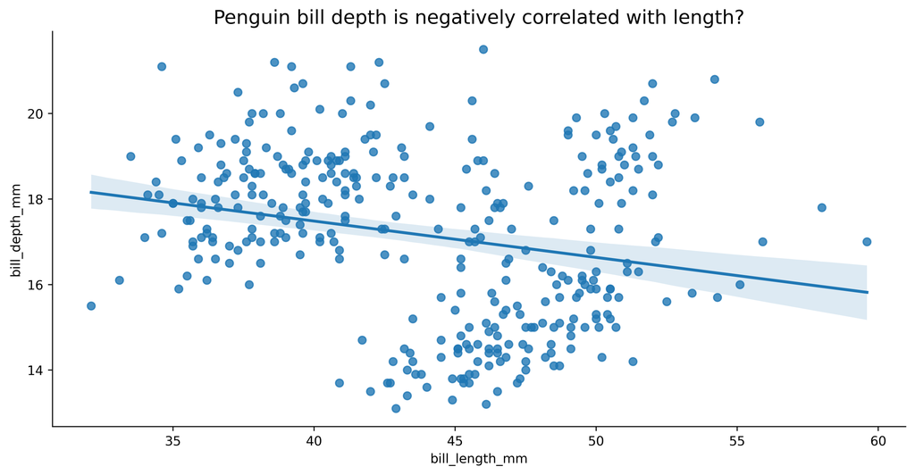

```python
sns.lmplot(penguins, x='bill_length_mm', y='bill_depth_mm', aspect = 2)
plt.title('Penguin bill depth is negatively correlated with length?', fontsize = 15);
```

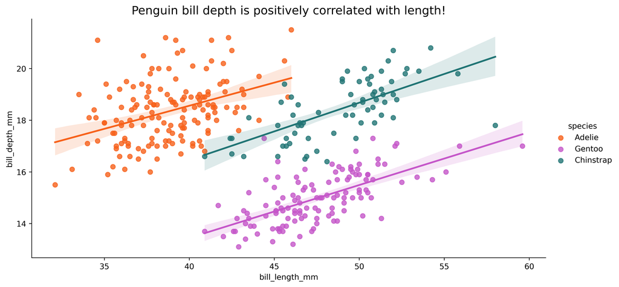

```python
sns.lmplot(penguins, x='bill_length_mm', y='bill_depth_mm', aspect = 2,
           hue='species', palette = ['#F7611A', '#C556C9', '#207474'])
plt.title('Penguin bill depth is positively correlated with length!', fontsize = 15);
```

# Vignette: Citizen science project "Galiwatch''

- Based on Galiano Island, British Columbia
- Microclimate monitoring (temperature, air particles, weather, etc)
- Tracking hummingbirds visiting the area

https://galiwatch.ca/

## Two humming bird species: Anna and Rufous

[figure not shown]

https://www.allaboutbirds.org/

## Data cleaning

- Cleaned up timestamps
- Missing data
- Merged bird detection and weather data (collected at different intervals)

```python
# Libraries we'll use
import pandas as pd
import numpy as np
import matplotlib.pyplot as plt
import seaborn as sns
```

```python
# Load weather station data
weather = pd.read_csv('WS_hours.csv', na_values=['Nan', '--.-- ', '-- '])
# Format the timestamps
weather['timestamp'] = pd.to_datetime(weather.Date.astype(str).str[0:4] +
                                      '-' + weather.Date.astype(str).str[4:6] +
                                      '-' + weather.Date.astype(str).str[6:8] +
                                      ' ' + weather.Time)
# Convert to celsius
weather['Temperature C'] = (weather['Outdoor Temperature F'] - 32) * 5/9
```

```python
# Load bird classifier data
bird = pd.read_csv('bird_detection.csv', index_col=0)
# Format timestamps
timestamp = bird['image'].str.split('.', expand=True)[0].str.replace('_', ' ')
bird['timestamp'] = pd.to_datetime(timestamp.str[0:13] +
                                   ':' + timestamp.str[13:15] + ":00")
```

```python
# Merge datasets
weather['merge_time'] = weather.timestamp.dt.strftime('%Y-%m-%d %H')
bird['merge_time'] = bird.timestamp.dt.strftime('%Y-%m-%d %H')
data = weather.merge(bird, on = 'merge_time', how = 'left')
```

## Back to the EDA checklist

[figure not shown]

## Look at the data! 👀

```python
data
```

|  | Timestamp | xmin | ymin | xmax | ymax | label | confidence | Temperature C | Outdoor Humidity % | Wind Speed(mph) | ... | wind gust | Wind Speed average | Daily Rainfall accumulation | Total Accumulative Rainfall | bird_spotted | Sex | Species | Date | Hour | Month |
| --- | --- | --- | --- | --- | --- | --- | --- | --- | --- | --- | --- | --- | --- | --- | --- | --- | --- | --- | --- | --- | --- |
| 1267 | 2021-04-20 17:00:00 | 626.0 | 404.0 | 820.0 | 544.0 | 0.0 | 0.983709 | 17.833333 | 32 | 2 | ... | 2 | 2 | 0.00 | 0.59 | True | Male | Rufous | 2021-04-20 | 17 | 4 |
| 53167 | 2021-04-20 17:00:00 | 626.0 | 404.0 | 820.0 | 544.0 | 0.0 | 0.983709 | 17.833333 | 32 | 2 | ... | 2 | 2 | 0.00 | 0.59 | True | Male | Rufous | 2021-04-20 | 17 | 4 |
| 53166 | 2021-04-20 17:00:00 | 222.0 | 384.0 | 386.0 | 474.0 | 0.0 | 0.978049 | 17.833333 | 32 | 2 | ... | 2 | 2 | 0.00 | 0.59 | True | Male | Rufous | 2021-04-20 | 17 | 4 |
| 1266 | 2021-04-20 17:00:00 | 222.0 | 384.0 | 386.0 | 474.0 | 0.0 | 0.978049 | 17.833333 | 32 | 2 | ... | 2 | 2 | 0.00 | 0.59 | True | Male | Rufous | 2021-04-20 | 17 | 4 |
| 27223 | 2021-04-20 17:00:00 | 626.0 | 404.0 | 820.0 | 544.0 | 0.0 | 0.983709 | 17.833333 | 32 | 2 | ... | 2 | 2 | 0.00 | 0.59 | True | Male | Rufous | 2021-04-20 | 17 | 4 |
| ... | ... | ... | ... | ... | ... | ... | ... | ... | ... | ... | ... | ... | ... | ... | ... | ... | ... | ... | ... | ... | ... |
| 77527 | 2021-10-16 11:00:00 | NaN | NaN | NaN | NaN | NaN | NaN | 11.388889 | 97 | 0 | ... | 1 | 0 | 0.56 | 7.96 | False | NaN | NaN | 2021-10-16 | 11 | 10 |
| 51583 | 2021-10-16 11:00:00 | NaN | NaN | NaN | NaN | NaN | NaN | 11.388889 | 97 | 0 | ... | 1 | 0 | 0.56 | 7.96 | False | NaN | NaN | 2021-10-16 | 11 | 10 |
| 51584 | 2021-10-16 12:00:00 | 604.0 | 339.0 | 706.0 | 443.0 | 1.0 | 0.829207 | 11.611111 | 97 | 1 | ... | 1 | 0 | 0.57 | 7.97 | True | Male | Anna | 2021-10-16 | 12 | 10 |
| 77528 | 2021-10-16 12:00:00 | 604.0 | 339.0 | 706.0 | 443.0 | 1.0 | 0.829207 | 11.611111 | 97 | 1 | ... | 1 | 0 | 0.57 | 7.97 | True | Male | Anna | 2021-10-16 | 12 | 10 |
| 25628 | 2021-10-16 12:00:00 | 604.0 | 339.0 | 706.0 | 443.0 | 1.0 | 0.829207 | 11.611111 | 97 | 1 | ... | 1 | 0 | 0.57 | 7.97 | True | Male | Anna | 2021-10-16 | 12 | 10 |

73089 rows × 26 columns

## What do the variables mean?

| Variable Name | Description |
| --- | --- |
| Timestamp | timestamp of image containing identified object |
| xmin, xmax, ymin, ymax | borders of an object bounding box |
| label | predicted object class label |
| confidence | prediction confidence |
| Temperature C | hourly average temperature (in celsius) |

[figure not shown]

## What do the labels mean?

| Label | Class |
| --- | --- |
| 0 | Rufous_Male |
| 1 | Annas_Male |
| 2 | Rufous_Female |
| 3 | Person |
| 4 | Annas_Female |

### Assumption: data is representative

```python
data.shape
```

```
(73089, 26)
```

```python
print('Dataset spans from ' + str(data['Date'].min()) +
      ' to ' + str(data['Date'].max()))
```

```
Dataset spans from 2021-04-20 to 2021-10-16
```

### Assumption: probably should filter out the low-confidence predictions, and the people

```python
data = data[(data['confidence'] > 0.7) | (data['confidence'].isna())]
data = data[data['label'] != 3]
```

## Exploratory plots

Histograms, scatterplots are good for getting a feel for your data

Quick statistical diagnostics can be very useful (R-square, p-test, QQ plot)

## What was summer 2021 like?

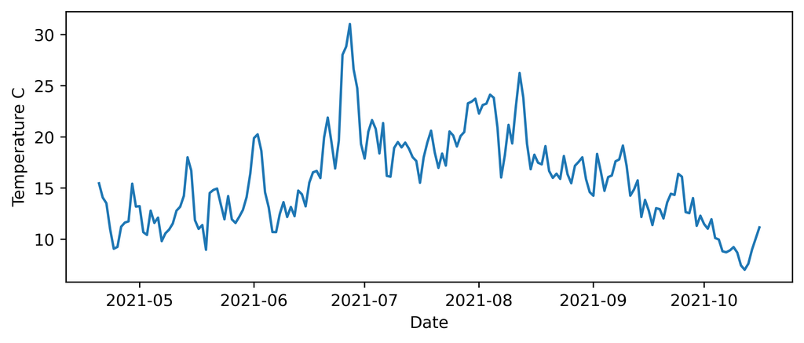

```python
fig, ax = plt.subplots(1,1, figsize = (8,3))
sns.lineplot(data, x='Date', y='Temperature C', ci=False);
```

### Conclusion: Temperature peaks in early July

## What is the relationship between different weather variables?

```python
df = data[['Hour', 'Temperature C', 'Outdoor Humidity %',
              'Dew Point']].groupby(['Hour'], as_index=False).mean()
sns.pairplot(df, diag_kind="kde", corner=True, palette="viridis")
plt.close()
```

[figure not shown]

### Conclusion: Peak daily temperature is around 3pm. With increased temperature, we generally see decreased humidity.

## Investigate circular Dew Point

```python
df = data[['Month', 'Hour', 'Temperature C', 'Outdoor Humidity %',
              'Dew Point']].groupby(['Month','Hour'], as_index=False).mean()
sns.pairplot(df, diag_kind="kde", corner=True, hue = 'Month',  palette="viridis", diag_kws={'hue': None})
plt.close()
```

[figure not shown]

### Conclusion: Relationship between Dew Point, Temperature, and Humidity chages over the season

## When in the year do birds visit the feeder?

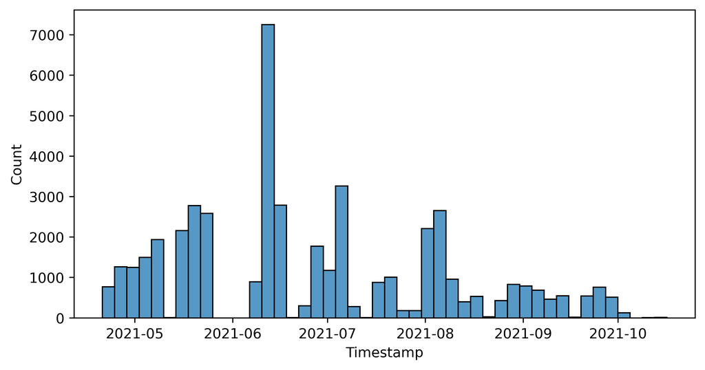

```python
sns.histplot(data[data['bird_spotted'] == True], x = 'Timestamp');
```

### Conclusion: Birds visit most in June - August

## When in the day do birds visit the feeder?

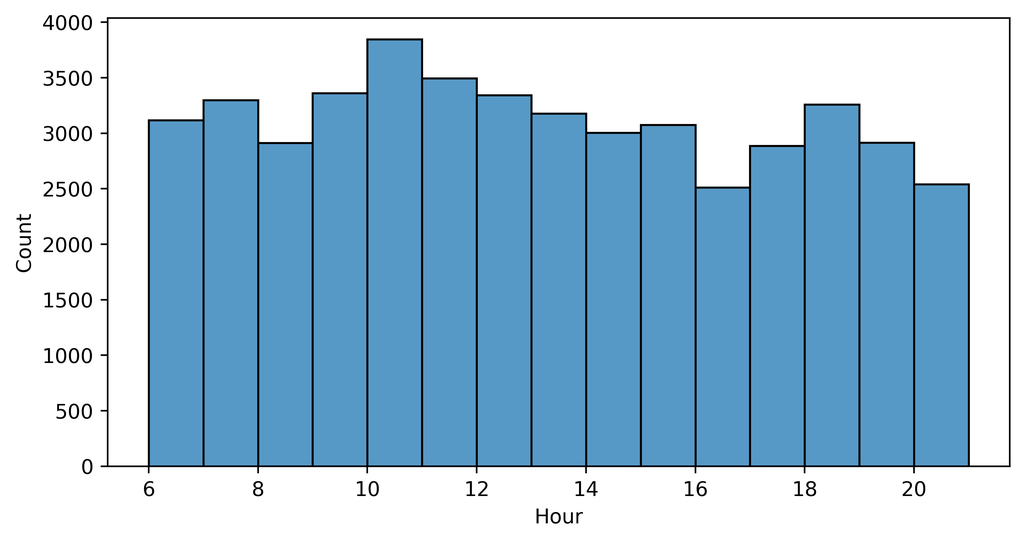

```python
sns.histplot(data[data['bird_spotted'] == True], x='Hour', binwidth=1);
```

### Conclusion: Birds visit in the day between 6am and 9pm

## Do birds care about the weather?

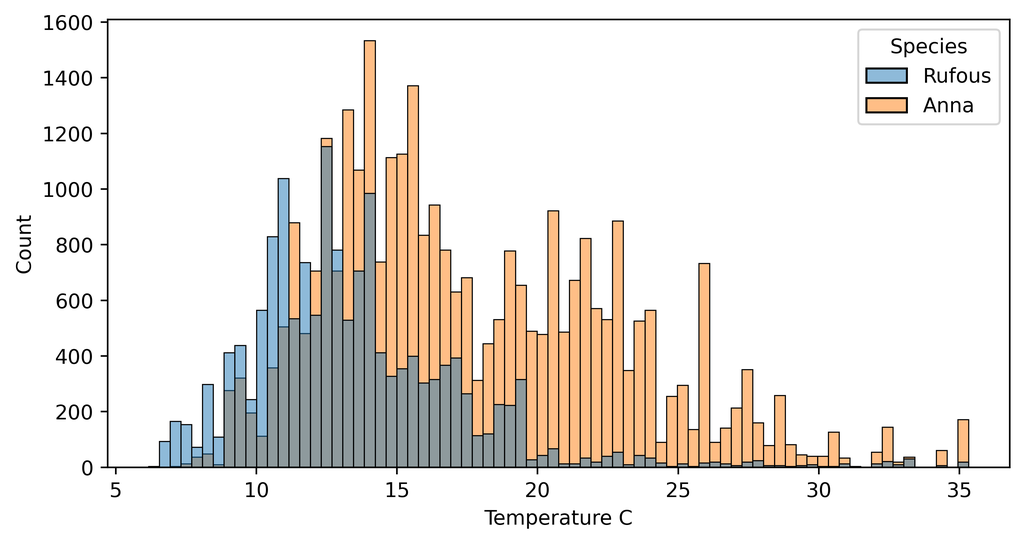

```python
sns.histplot(data[data['bird_spotted'] == True], x ='Temperature C', hue = 'Species');
```

### Conclusion: Anna's humming bird prefers hotter weather

## Talk to an expert

I brought my exploratory plots to an expert, and went through the preliminary conclusions:

- Temperature peaks in early July
- Peak daily temperature is around 3pm. With increased temperature, we generally see decreased humidity.
- Relationship between Dew Point, Temperature, and Humidity chages over the season
- Birds visit most in June - August
- Birds visit in the day between 6am and 9pm
- Anna's humming bird prefers hotter weather

## Talk to an expert

I brought my exploratory plots to an expert, and went through the preliminary conclusions:

- **Temperature peaks in early July**
- Peak daily temperature is around 3pm. With increased temperature, we generally see decreased humidity.
- Relationship between Dew Point, Temperature, and Humidity chages over the season
- Birds visit most in June - August
- **Birds visit in the day between 6am and 9pm**
- **Anna's humming bird prefers hotter weather**

## I learned that the Anna and Rufous birds have different migration patterns.

[figure not shown]

Modified from Wikipedia

## Back to the drawing board

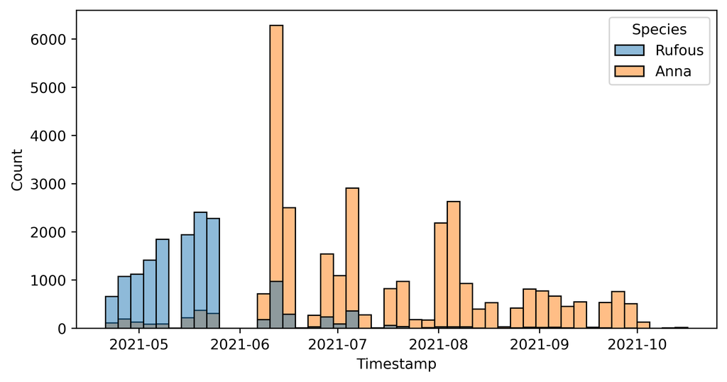

```python
sns.histplot(data, x = 'Timestamp', hue ='Species');
```

### Conclusion: Rufous migrate away around June, then Annas arrive

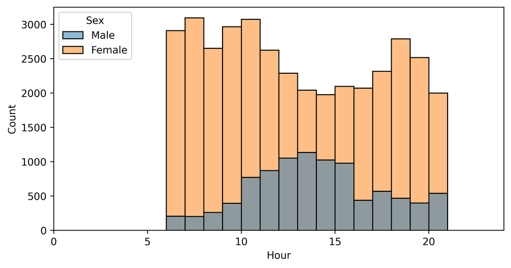

```python
sns.histplot(data, x='Hour', binwidth=1, hue = "Sex");
plt.xlim(0,24);
```

### Conclusion: Male & female birds visit at different times of the day

# Story telling plots

## Conclusions our plots should hightlight:

- Species visit at different times of the year
- Male & female birds visit at different times of the day
- Temperature and migration are confounded

## Visual encoding

[figure not shown]

Visualization Analysis and Design by Tamara Munzner

```python
# Colour pallettes
species_pal = {'Anna':'#226F54', 'Rufous':'#DA7635'}  # green & orange
anna_pal = {'Male': '#1D5D47', 'Female': '#92DDC3'}   # dark & light green
rufous_pal = {'Male': '#793E16', 'Female': '#E39764'} # dark & light orange
```

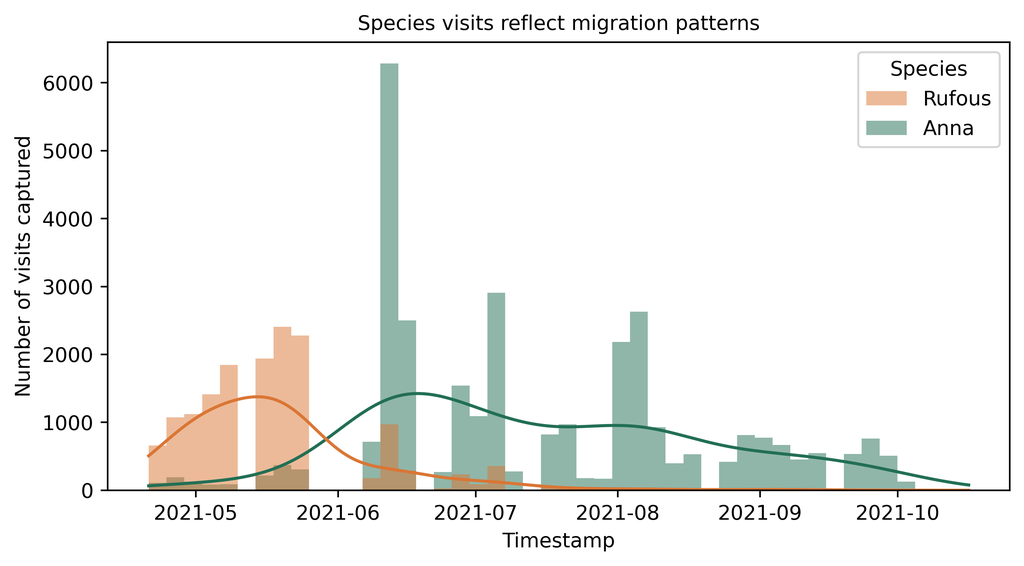

```python
fig, ax = plt.subplots(1,1)
sns.histplot(data, x = 'Timestamp', hue='Species', edgecolor=None,  palette=species_pal, kde=True, kde_kws={'bw_adjust':3})
ax.set_ylabel('Number of visits captured')
plt.title('Species visits reflect migration patterns', fontsize=10);
```

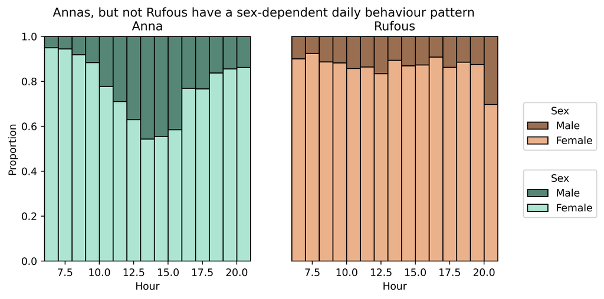

```python
data['Hour'] = data.Timestamp.dt.hour
fix, ax = plt.subplots(1,2)
sns.histplot(data[data['Species'] == 'Anna'], x='Hour', hue = 'Sex', multiple="fill", stat="proportion", palette=anna_pal, binwidth=1, ax=ax[0])
sns.histplot(data[data['Species'] == 'Rufous'], x='Hour', hue = 'Sex', multiple="fill", stat="proportion", palette=rufous_pal, binwidth=1, ax=ax[1])
ax[0].set_title('Anna')
ax[1].set_title('Rufous')
ax[1].get_yaxis().set_visible(False)
sns.move_legend(ax[0], "center left", bbox_to_anchor=(2.3, 0.3))
sns.move_legend(ax[1], "center left", bbox_to_anchor=(1.1, 0.6))
plt.suptitle('Annas, but not Rufous have a sex-dependent daily behaviour pattern');
```

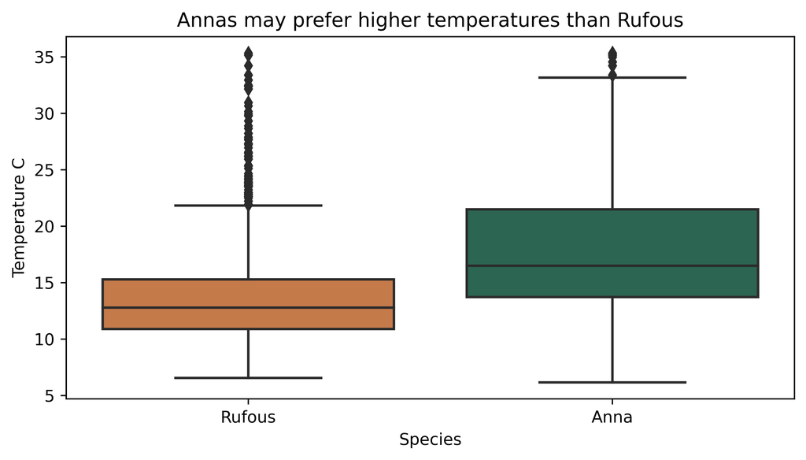

```python
sns.boxplot(data, y='Temperature C', x = 'Species', palette=species_pal)
plt.title('Annas may prefer higher temperatures than Rufous');
```

```python
from scipy.stats import ttest_ind
group1 = data['Temperature C'][(data['Species'] =='Anna')].dropna()
group2 = data['Temperature C'][(data['Species'] =='Rufous')].dropna()

ttest_ind(group1, group2)
```

```
Ttest_indResult(statistic=90.0467639582544, pvalue=0.0)
```

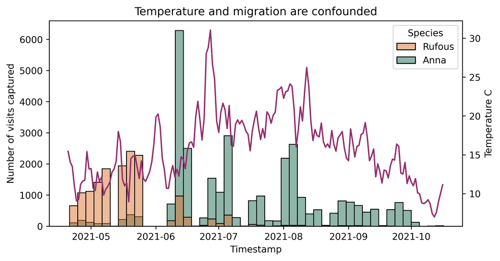

```python
fig, ax = plt.subplots(1,1)
sns.histplot(data, x = 'Timestamp', hue ='Species', palette=species_pal)
ax.set_ylabel('Number of visits captured')
ax2 = ax.twinx()
sns.lineplot(data, x='Date', y='Temperature C', ax = ax2, ci=False, color ='#932F6D');
plt.title("Temperature and migration are confounded");
```

### These plots are far from perfect from a design perspective, but the point is to show the distinction between the EDA iteration and story telling.

[figure not shown]

# Thanks!

### Find these slides at: https://caitharrigan.ca/slides/hummingbird_eda.slides.html

[figure not shown]